# Part I - Prosper loan data Exploration

## Introduction

Dataset contains loan information from prosper, having 113937 rows of loan listings with 81 columns. It features columns like 'LoanStatus', 'ClosedDate','BorrowerAPR','BorrowerRate','Occupation', 'CreditScoreRangeLower',EmploymentStatus','DebtToIncomeRatio',IncomeRange', 'TotalProsperLoans','MonthlyLoanPayment'.

#### Data Dictionary:

https://docs.google.com/spreadsheets/d/1k60B40cr0YAR51X8dmqLGyYBqKzN80Vm2Pnxx3GtHcw/edit?usp=sharing

Prosper was founded in 2005 as the first peer-to-peer lending marketplace in the United States. Since then, Prosper has facilitated more than USD 12 billion in loans to more than 770,000 people. Through Prosper, people can invest in each other in a way that is financially and socially rewarding. Borrowers apply online for a fixed-rate, fixed-term loan between USD 2,000 and USD 40,000. Individuals and institutions can invest in the loans and earn attractive returns. Prosper handles all loan servicing on behalf of the matched borrowers and investors. (source: https://www.prosper.com/about)

Following are some of the key points or questions I am looking for in the dataset.

#### Problem statement:

1. Does owning home impacts borrowers eligibility of loan amount, interest rate irrespective of their credit score and income range?
2. Is there change in borrower rate over the period?
3. Does monthly income have any association with interest rate?

## Preliminary Wrangling

```python
# importing all packages and setting plots to be embedded inline
import numpy as np
import pandas as pd
import matplotlib.pyplot as plt
import seaborn as sns
%matplotlib inline
```

```python
# Loading data in notebook using pandas and inspecting visually
df = pd.read_csv('prosperLoanData.csv')
pd.set_option('display.max_columns', 85) # to display all columns when viewing data
pd.set_option('display.max_rows', None) # to display all rows in the output
df.head()
```

|  | ListingKey | ListingNumber | ListingCreationDate | CreditGrade | Term | LoanStatus | ClosedDate | BorrowerAPR | BorrowerRate | LenderYield | EstimatedEffectiveYield | EstimatedLoss | EstimatedReturn | ProsperRating (numeric) | ProsperRating (Alpha) | ProsperScore | ListingCategory (numeric) | BorrowerState | Occupation | EmploymentStatus | EmploymentStatusDuration | IsBorrowerHomeowner | CurrentlyInGroup | GroupKey | DateCreditPulled | CreditScoreRangeLower | CreditScoreRangeUpper | FirstRecordedCreditLine | CurrentCreditLines | … |
| --- | --- | --- | --- | --- | --- | --- | --- | --- | --- | --- | --- | --- | --- | --- | --- | --- | --- | --- | --- | --- | --- | --- | --- | --- | --- | --- | --- | --- | --- | --- |
| 0 | 1021339766868145413AB3B | 193129 | 2007-08-26 19:09:29.263000000 | C | 36 | Completed | 2009-08-14 00:00:00 | 0.16516 | 0.1580 | 0.1380 | NaN | NaN | NaN | NaN | NaN | NaN | 0 | CO | Other | Self-employed | 2.0 | True | True | NaN | 2007-08-26 18:41:46.780000000 | 640.0 | 659.0 | 2001-10-11 00:00:00 | 5.0 | … |
| 1 | 10273602499503308B223C1 | 1209647 | 2014-02-27 08:28:07.900000000 | NaN | 36 | Current | NaN | 0.12016 | 0.0920 | 0.0820 | 0.07960 | 0.0249 | 0.05470 | 6.0 | A | 7.0 | 2 | CO | Professional | Employed | 44.0 | False | False | NaN | 2014-02-27 08:28:14 | 680.0 | 699.0 | 1996-03-18 00:00:00 | 14.0 | … |
| 2 | 0EE9337825851032864889A | 81716 | 2007-01-05 15:00:47.090000000 | HR | 36 | Completed | 2009-12-17 00:00:00 | 0.28269 | 0.2750 | 0.2400 | NaN | NaN | NaN | NaN | NaN | NaN | 0 | GA | Other | Not available | NaN | False | True | 783C3371218786870A73D20 | 2007-01-02 14:09:10.060000000 | 480.0 | 499.0 | 2002-07-27 00:00:00 | NaN | … |
| 3 | 0EF5356002482715299901A | 658116 | 2012-10-22 11:02:35.010000000 | NaN | 36 | Current | NaN | 0.12528 | 0.0974 | 0.0874 | 0.08490 | 0.0249 | 0.06000 | 6.0 | A | 9.0 | 16 | GA | Skilled Labor | Employed | 113.0 | True | False | NaN | 2012-10-22 11:02:32 | 800.0 | 819.0 | 1983-02-28 00:00:00 | 5.0 | … |
| 4 | 0F023589499656230C5E3E2 | 909464 | 2013-09-14 18:38:39.097000000 | NaN | 36 | Current | NaN | 0.24614 | 0.2085 | 0.1985 | 0.18316 | 0.0925 | 0.09066 | 3.0 | D | 4.0 | 2 | MN | Executive | Employed | 44.0 | True | False | NaN | 2013-09-14 18:38:44 | 680.0 | 699.0 | 2004-02-20 00:00:00 | 19.0 | … |

```python
# Structure of the dataset
df.shape
```

```
(113937, 81)
```

```python
# Getting columns
df.columns
```

```
Index(['ListingKey', 'ListingNumber', 'ListingCreationDate', 'CreditGrade',
       'Term', 'LoanStatus', 'ClosedDate', 'BorrowerAPR', 'BorrowerRate',
       'LenderYield', 'EstimatedEffectiveYield', 'EstimatedLoss',
       'EstimatedReturn', 'ProsperRating (numeric)', 'ProsperRating (Alpha)',
       'ProsperScore', 'ListingCategory (numeric)', 'BorrowerState',
       'Occupation', 'EmploymentStatus', 'EmploymentStatusDuration',
       'IsBorrowerHomeowner', 'CurrentlyInGroup', 'GroupKey',
       'DateCreditPulled', 'CreditScoreRangeLower', 'CreditScoreRangeUpper',
       'FirstRecordedCreditLine', 'CurrentCreditLines', 'OpenCreditLines',
       'TotalCreditLinespast7years', 'OpenRevolvingAccounts',
       'OpenRevolvingMonthlyPayment', 'InquiriesLast6Months', 'TotalInquiries',
       'CurrentDelinquencies', 'AmountDelinquent', 'DelinquenciesLast7Years',
       'PublicRecordsLast10Years', 'PublicRecordsLast12Months',
       'RevolvingCreditBalance', 'BankcardUtilization',
       'AvailableBankcardCredit', 'TotalTrades',
       'TradesNeverDelinquent (percentage)', 'TradesOpenedLast6Months',
       'DebtToIncomeRatio', 'IncomeRange', 'IncomeVerifiable',
       'StatedMonthlyIncome', 'LoanKey', 'TotalProsperLoans',
       'TotalProsperPaymentsBilled', 'OnTimeProsperPayments',
       'ProsperPaymentsLessThanOneMonthLate',
       'ProsperPaymentsOneMonthPlusLate', 'ProsperPrincipalBorrowed',
       'ProsperPrincipalOutstanding', 'ScorexChangeAtTimeOfListing',
       'LoanCurrentDaysDelinquent', 'LoanFirstDefaultedCycleNumber',
       'LoanMonthsSinceOrigination', 'LoanNumber', 'LoanOriginalAmount',
       'LoanOriginationDate', 'LoanOriginationQuarter', 'MemberKey',
       'MonthlyLoanPayment', 'LP_CustomerPayments',
       'LP_CustomerPrincipalPayments', 'LP_InterestandFees', 'LP_ServiceFees',
       'LP_CollectionFees', 'LP_GrossPrincipalLoss', 'LP_NetPrincipalLoss',
       'LP_NonPrincipalRecoverypayments', 'PercentFunded', 'Recommendations',
       'InvestmentFromFriendsCount', 'InvestmentFromFriendsAmount',
       'Investors'],
      dtype='object')
```

```python
# Due to higher number of column checking stats partly
df.iloc[:,:20].describe().T
```

|  | count | mean | std | min | 25% | 50% | 75% | max |
| --- | --- | --- | --- | --- | --- | --- | --- | --- |
| ListingNumber | 113937.0 | 627885.692506 | 328076.236386 | 4.00000 | 400919.00000 | 600554.00000 | 892634.00000 | 1.255725e+06 |
| Term | 113937.0 | 40.830248 | 10.436212 | 12.00000 | 36.00000 | 36.00000 | 36.00000 | 6.000000e+01 |
| BorrowerAPR | 113912.0 | 0.218828 | 0.080364 | 0.00653 | 0.15629 | 0.20976 | 0.28381 | 5.122900e-01 |
| BorrowerRate | 113937.0 | 0.192764 | 0.074818 | 0.00000 | 0.13400 | 0.18400 | 0.25000 | 4.975000e-01 |
| LenderYield | 113937.0 | 0.182701 | 0.074516 | -0.01000 | 0.12420 | 0.17300 | 0.24000 | 4.925000e-01 |
| EstimatedEffectiveYield | 84853.0 | 0.168661 | 0.068467 | -0.18270 | 0.11567 | 0.16150 | 0.22430 | 3.199000e-01 |
| EstimatedLoss | 84853.0 | 0.080306 | 0.046764 | 0.00490 | 0.04240 | 0.07240 | 0.11200 | 3.660000e-01 |
| EstimatedReturn | 84853.0 | 0.096068 | 0.030403 | -0.18270 | 0.07408 | 0.09170 | 0.11660 | 2.837000e-01 |
| ProsperRating (numeric) | 84853.0 | 4.072243 | 1.673227 | 1.00000 | 3.00000 | 4.00000 | 5.00000 | 7.000000e+00 |
| ProsperScore | 84853.0 | 5.950067 | 2.376501 | 1.00000 | 4.00000 | 6.00000 | 8.00000 | 1.100000e+01 |
| ListingCategory (numeric) | 113937.0 | 2.774209 | 3.996797 | 0.00000 | 1.00000 | 1.00000 | 3.00000 | 2.000000e+01 |

##### Observations:

- Loan period ranges from an year to 5 years.75% of loan listing are within 3 years.
- Max Interest rate is 49.75%. Three fourth of loans borrower rate lies within 25%.

```python
# Due to higher number of column checking stats partly
df.iloc[:,20:40].describe().T
```

|  | count | mean | std | min | 25% | 50% | 75% | max |
| --- | --- | --- | --- | --- | --- | --- | --- | --- |
| EmploymentStatusDuration | 106312.0 | 96.071582 | 94.480605 | 0.0 | 26.0 | 67.0 | 137.0 | 755.0 |
| CreditScoreRangeLower | 113346.0 | 685.567731 | 66.458275 | 0.0 | 660.0 | 680.0 | 720.0 | 880.0 |
| CreditScoreRangeUpper | 113346.0 | 704.567731 | 66.458275 | 19.0 | 679.0 | 699.0 | 739.0 | 899.0 |
| CurrentCreditLines | 106333.0 | 10.317192 | 5.457866 | 0.0 | 7.0 | 10.0 | 13.0 | 59.0 |
| OpenCreditLines | 106333.0 | 9.260164 | 5.022644 | 0.0 | 6.0 | 9.0 | 12.0 | 54.0 |
| TotalCreditLinespast7years | 113240.0 | 26.754539 | 13.637871 | 2.0 | 17.0 | 25.0 | 35.0 | 136.0 |
| OpenRevolvingAccounts | 113937.0 | 6.969790 | 4.630970 | 0.0 | 4.0 | 6.0 | 9.0 | 51.0 |
| OpenRevolvingMonthlyPayment | 113937.0 | 398.292161 | 447.159711 | 0.0 | 114.0 | 271.0 | 525.0 | 14985.0 |
| InquiriesLast6Months | 113240.0 | 1.435085 | 2.437507 | 0.0 | 0.0 | 1.0 | 2.0 | 105.0 |
| TotalInquiries | 112778.0 | 5.584405 | 6.429946 | 0.0 | 2.0 | 4.0 | 7.0 | 379.0 |
| CurrentDelinquencies | 113240.0 | 0.592052 | 1.978707 | 0.0 | 0.0 | 0.0 | 0.0 | 83.0 |
| AmountDelinquent | 106315.0 | 984.507059 | 7158.270157 | 0.0 | 0.0 | 0.0 | 0.0 | 463881.0 |
| DelinquenciesLast7Years | 112947.0 | 4.154984 | 10.160216 | 0.0 | 0.0 | 0.0 | 3.0 | 99.0 |
| PublicRecordsLast10Years | 113240.0 | 0.312646 | 0.727868 | 0.0 | 0.0 | 0.0 | 0.0 | 38.0 |
| PublicRecordsLast12Months | 106333.0 | 0.015094 | 0.154092 | 0.0 | 0.0 | 0.0 | 0.0 | 20.0 |

##### Observations:

- Average credit score lower is 685 with max of 880
- Average credit score upper is 704 with max of 899

```python
# Due to higher number of columns checking stats partly
df.iloc[:,40:60].describe().T
```

|  | count | mean | std | min | 25% | 50% | 75% | max |
| --- | --- | --- | --- | --- | --- | --- | --- | --- |
| RevolvingCreditBalance | 106333.0 | 17598.706751 | 32936.401788 | 0.0 | 3121.000000 | 8549.000000 | 19521.00 | 1.435667e+06 |
| BankcardUtilization | 106333.0 | 0.561309 | 0.317918 | 0.0 | 0.310000 | 0.600000 | 0.84 | 5.950000e+00 |
| AvailableBankcardCredit | 106393.0 | 11210.225447 | 19818.361309 | 0.0 | 880.000000 | 4100.000000 | 13180.00 | 6.462850e+05 |
| TotalTrades | 106393.0 | 23.230034 | 11.871311 | 0.0 | 15.000000 | 22.000000 | 30.00 | 1.260000e+02 |
| TradesNeverDelinquent (percentage) | 106393.0 | 0.885897 | 0.148179 | 0.0 | 0.820000 | 0.940000 | 1.00 | 1.000000e+00 |
| TradesOpenedLast6Months | 106393.0 | 0.802327 | 1.097637 | 0.0 | 0.000000 | 0.000000 | 1.00 | 2.000000e+01 |
| DebtToIncomeRatio | 105383.0 | 0.275947 | 0.551759 | 0.0 | 0.140000 | 0.220000 | 0.32 | 1.001000e+01 |
| StatedMonthlyIncome | 113937.0 | 5608.025568 | 7478.497275 | 0.0 | 3200.333333 | 4666.666667 | 6825.00 | 1.750003e+06 |
| TotalProsperLoans | 22085.0 | 1.421100 | 0.764042 | 0.0 | 1.000000 | 1.000000 | 2.00 | 8.000000e+00 |
| TotalProsperPaymentsBilled | 22085.0 | 22.934345 | 19.249584 | 0.0 | 9.000000 | 16.000000 | 33.00 | 1.410000e+02 |
| OnTimeProsperPayments | 22085.0 | 22.271949 | 18.830425 | 0.0 | 9.000000 | 15.000000 | 32.00 | 1.410000e+02 |
| ProsperPaymentsLessThanOneMonthLate | 22085.0 | 0.613629 | 2.446827 | 0.0 | 0.000000 | 0.000000 | 0.00 | 4.200000e+01 |
| ProsperPaymentsOneMonthPlusLate | 22085.0 | 0.048540 | 0.556285 | 0.0 | 0.000000 | 0.000000 | 0.00 | 2.100000e+01 |
| ProsperPrincipalBorrowed | 22085.0 | 8472.311961 | 7395.507650 | 0.0 | 3500.000000 | 6000.000000 | 11000.00 | 7.249900e+04 |
| ProsperPrincipalOutstanding | 22085.0 | 2930.313906 | 3806.635075 | 0.0 | 0.000000 | 1626.550000 | 4126.72 | 2.345095e+04 |
| ScorexChangeAtTimeOfListing | 18928.0 | -3.223214 | 50.063567 | -209.0 | -35.000000 | -3.000000 | 25.00 | 2.860000e+02 |
| LoanCurrentDaysDelinquent | 113937.0 | 152.816539 | 466.320254 | 0.0 | 0.000000 | 0.000000 | 0.00 | 2.704000e+03 |

##### Observations:

- Average debtincome ratio is 0.27 with max of 10.Need to check some peoples debt are ten times of their income.
- Max monthly income is more than million, have to check for outliers
- Prosper titled columns has only 22085 values in their column, there must be lot of null values

```python
# Due to higher number of column checking stats partly
df.iloc[:,60:].describe().T
```

|  | count | mean | std | min | 25% | 50% | 75% | max |
| --- | --- | --- | --- | --- | --- | --- | --- | --- |
| LoanFirstDefaultedCycleNumber | 16952.0 | 16.268464 | 9.005898 | 0.0000 | 9.00 | 14.0000 | 22.00 | 44.0000 |
| LoanMonthsSinceOrigination | 113937.0 | 31.896882 | 29.974184 | 0.0000 | 6.00 | 21.0000 | 65.00 | 100.0000 |
| LoanNumber | 113937.0 | 69444.474271 | 38930.479610 | 1.0000 | 37332.00 | 68599.0000 | 101901.00 | 136486.0000 |
| LoanOriginalAmount | 113937.0 | 8337.013850 | 6245.800580 | 1000.0000 | 4000.00 | 6500.0000 | 12000.00 | 35000.0000 |
| MonthlyLoanPayment | 113937.0 | 272.475783 | 192.697812 | 0.0000 | 131.62 | 217.7400 | 371.58 | 2251.5100 |
| LP_CustomerPayments | 113937.0 | 4183.079489 | 4790.907234 | -2.3499 | 1005.76 | 2583.8300 | 5548.40 | 40702.3900 |
| LP_CustomerPrincipalPayments | 113937.0 | 3105.536588 | 4069.527670 | 0.0000 | 500.89 | 1587.5000 | 4000.00 | 35000.0000 |
| LP_InterestandFees | 113937.0 | 1077.542901 | 1183.414168 | -2.3499 | 274.87 | 700.8401 | 1458.54 | 15617.0300 |
| LP_ServiceFees | 113937.0 | -54.725641 | 60.675425 | -664.8700 | -73.18 | -34.4400 | -13.92 | 32.0600 |
| LP_CollectionFees | 113937.0 | -14.242698 | 109.232758 | -9274.7500 | 0.00 | 0.0000 | 0.00 | 0.0000 |
| LP_GrossPrincipalLoss | 113937.0 | 700.446342 | 2388.513831 | -94.2000 | 0.00 | 0.0000 | 0.00 | 25000.0000 |
| LP_NetPrincipalLoss | 113937.0 | 681.420499 | 2357.167068 | -954.5500 | 0.00 | 0.0000 | 0.00 | 25000.0000 |
| LP_NonPrincipalRecoverypayments | 113937.0 | 25.142686 | 275.657937 | 0.0000 | 0.00 | 0.0000 | 0.00 | 21117.9000 |
| PercentFunded | 113937.0 | 0.998584 | 0.017919 | 0.7000 | 1.00 | 1.0000 | 1.00 | 1.0125 |
| Recommendations | 113937.0 | 0.048027 | 0.332353 | 0.0000 | 0.00 | 0.0000 | 0.00 | 39.0000 |
| InvestmentFromFriendsCount | 113937.0 | 0.023460 | 0.232412 | 0.0000 | 0.00 | 0.0000 | 0.00 | 33.0000 |
| InvestmentFromFriendsAmount | 113937.0 | 16.550751 | 294.545422 | 0.0000 | 0.00 | 0.0000 | 0.00 | 25000.0000 |
| Investors | 113937.0 | 80.475228 | 103.239020 | 1.0000 | 2.00 | 44.0000 | 115.00 | 1189.0000 |

##### Observations:

```python
# Creating subset with required 23 columns for analysis
df_new = df[['ListingNumber','Term', 'LoanStatus','BorrowerAPR','ClosedDate',
 'BorrowerRate','LenderYield', 'ListingCategory (numeric)', 'BorrowerState','Occupation', 'EmploymentStatus',
 'IsBorrowerHomeowner', 'CreditScoreRangeLower','CreditScoreRangeUpper','DebtToIncomeRatio', 'IncomeRange',
 'IncomeVerifiable','StatedMonthlyIncome','LoanCurrentDaysDelinquent','LoanOriginalAmount','LoanOriginationDate','LoanOriginationQuarter','MonthlyLoanPayment']]
df_new.sample()
```

|  | ListingNumber | Term | LoanStatus | BorrowerAPR | ClosedDate | BorrowerRate | LenderYield | ListingCategory (numeric) | BorrowerState | Occupation | EmploymentStatus | IsBorrowerHomeowner | CreditScoreRangeLower | CreditScoreRangeUpper | DebtToIncomeRatio | IncomeRange | IncomeVerifiable | StatedMonthlyIncome | LoanCurrentDaysDelinquent | LoanOriginalAmount | LoanOriginationDate | LoanOriginationQuarter | MonthlyLoanPayment |
| --- | --- | --- | --- | --- | --- | --- | --- | --- | --- | --- | --- | --- | --- | --- | --- | --- | --- | --- | --- | --- | --- | --- | --- |
| 45528 | 1218572 | 36 | Current | 0.25677 | NaN | 0.2185 | 0.2085 | 1 | IN | Professor | Employed | False | 640.0 | 659.0 | 0.4 | $50,000-74,999 | True | 4166.666667 | 0 | 2500 | 2014-03-04 00:00:00 | Q1 2014 | 95.28 |

### What is the structure of your dataset?

> We have loan dataset of 113937 rows and 81 columns.

Subset using for analysis has 113937 loan listing rows with 23 columns.

### What is/are the main feature(s) of interest in your dataset?

> The BorrowerAPR,BorrowerRate, CreditScoreRange ,DebtToIncomeRatio,IncomeRange are the variables of focus for my problem statement.

### What features in the dataset do you think will help support your investigation into your feature(s) of interest?

> EmploymentStatus, IsHomeOwner, DoesIncomeVerifiable columns might help me in my investigation.

## Univariate Exploration

```python
df_new.isnull().sum()
```

```
ListingNumber                    0
Term                             0
LoanStatus                       0
BorrowerAPR                     25
ClosedDate                   58848
BorrowerRate                     0
LenderYield                      0
ListingCategory (numeric)        0
BorrowerState                 5515
Occupation                    3588
EmploymentStatus              2255
IsBorrowerHomeowner              0
CreditScoreRangeLower          591
CreditScoreRangeUpper          591
DebtToIncomeRatio             8554
IncomeRange                      0
IncomeVerifiable                 0
StatedMonthlyIncome              0
LoanCurrentDaysDelinquent        0
LoanOriginalAmount               0
LoanOriginationDate              0
LoanOriginationQuarter           0
MonthlyLoanPayment               0
dtype: int64
```

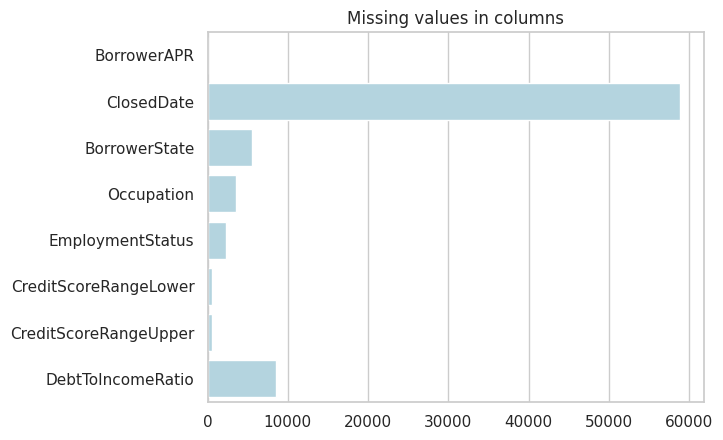

```python
# Finding columns which have missing values
null_col = []
null_count = []
for i in df_new.columns:
    if df_new[i].isnull().sum()>0:
        null_count.append(df_new[i].isnull().sum())
        null_col.append(i)
sns.barplot(y=null_col,x=null_count,color='lightblue')
plt.title('Missing values in columns');
```

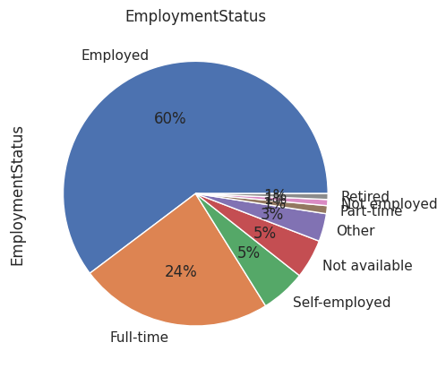

```python
# Distribution of employment status among prosper borrowers
df_new['EmploymentStatus'].value_counts().plot(kind='pie',autopct='%1.0f%%')
plt.title('EmploymentStatus');
```

- Shows distribution of employment status of people borrowed with prosper. Most of the borrowers are employed

```python
df_new['LoanStatus'].value_counts()
```

```
Current                   56576
Completed                 38074
Chargedoff                11992
Defaulted                  5018
Past Due (1-15 days)        806
Past Due (31-60 days)       363
Past Due (61-90 days)       313
Past Due (91-120 days)      304
Past Due (16-30 days)       265
FinalPaymentInProgress      205
Past Due (>120 days)         16
Cancelled                     5
Name: LoanStatus, dtype: int64
```

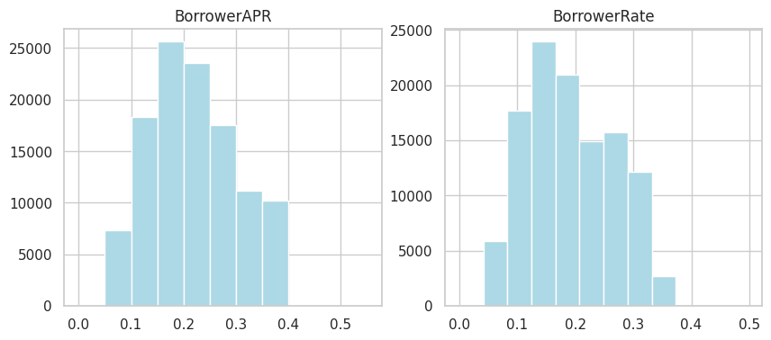

```python
# Creating histogram for BorrowerAPR and rate
plt.figure(figsize=(10,4))
plt.subplot(1,2,1)
bins = np.arange(0,df_new['BorrowerAPR'].max()+0.05,0.05)
plt.hist(df_new['BorrowerAPR'],bins=bins,color='lightblue')
plt.title('BorrowerAPR')
plt.subplot(1,2,2)
plt.hist(df_new['BorrowerRate'],bins=12,color='lightblue')
plt.title('BorrowerRate');
```

```python
# Removing Borrower rate from subset
df_new.drop('BorrowerRate',axis=1,inplace=True)
```

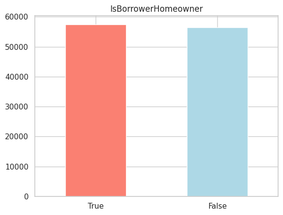

```python
# Ratio of homeowners
df_new['IsBorrowerHomeowner'].value_counts().plot(kind='bar', color=['salmon','lightblue'])
plt.title('IsBorrowerHomeowner')
plt.xticks(rotation=0);
```

- Half of borrower owns their home, A Borrower will be classified as a homowner if they have a mortgage on their credit profile or provide documentation confirming they are a homeowner.

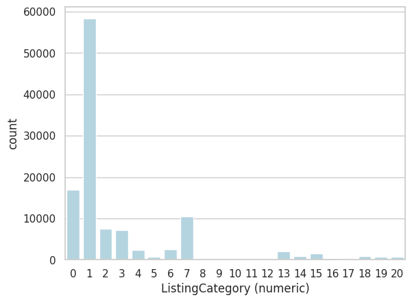

```python
# keep ListingCategory as int to easily keep the same order in all plots
sns.countplot(data = df_new, x = 'ListingCategory (numeric)', color = 'lightblue');
```

The dictionary for listing categories:

0. Not Available
1. Debt Consolidation
2. Home Improvement
3. Business
4. Personal Loan
5. Student Use
6. Auto
7. Other
8. Baby&Adoption
9. Boat
10. Cosmetic Procedure
11. Engagement Ring
12. Green Loans
13. Household Expenses
14. Large Purchases
15. Medical/Dental
16. Motorcycle
17. RV
18. Taxes
19. Vacation
20. Wedding Loans

Most loans are debt consolidation and many loans do not have a category defined. The distribution shows that ListingCategory might not be a very interesting variable for further analysis after all.

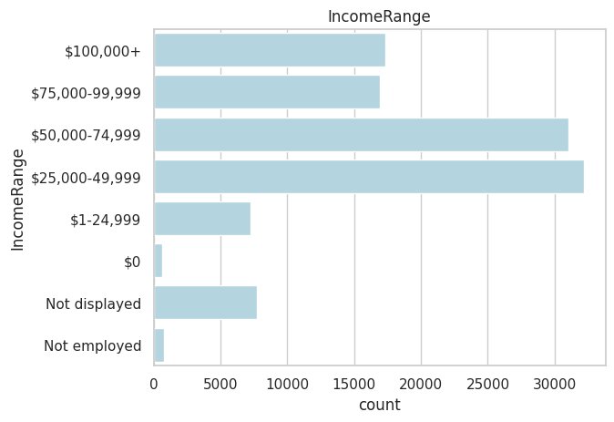

```python
# Inspecting income range of borrowers
order = ['$100,000+','$75,000-99,999','$50,000-74,999','$25,000-49,999','$1-24,999','$0','Not displayed','Not employed']
sns.countplot(data=df_new,y='IncomeRange',color='lightblue',order=order)
plt.title('IncomeRange');
```

- Zero can be replaced with Not employed
- Almost 60% of borrowers falls in the income range of \$25000 to $75000

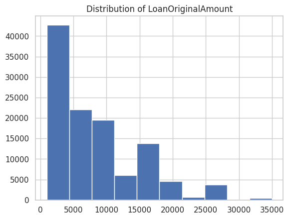

```python
# Loan original amount distribution
df_new['LoanOriginalAmount'].hist()
plt.title('Distribution of LoanOriginalAmount');
# This clearly right skewed, Most of the borrowings within USD 10000
```

- Loan original amount ranges from USD 1000 to USD 35000

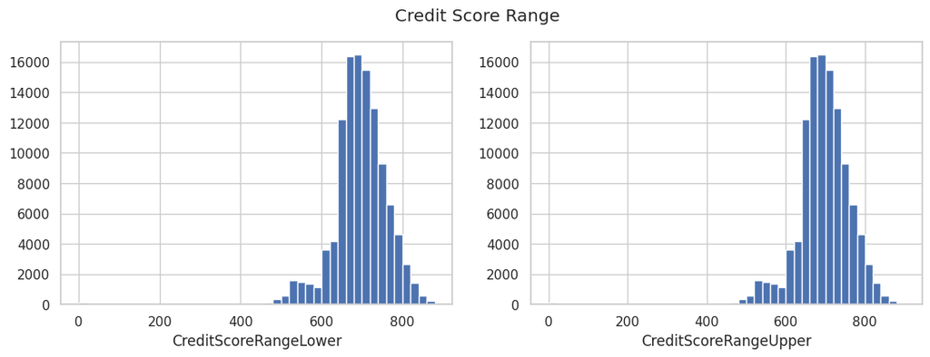

```python
# Distribution of Credit score
plt.figure(figsize=(13,4))
plt.suptitle("Credit Score Range")
plt.subplot(1,2,1)
bins_lower = np.arange(0, df.CreditScoreRangeLower.max()+20, 20)
plt.hist(data = df, x = 'CreditScoreRangeLower', bins = bins_lower)
plt.xlabel('CreditScoreRangeLower')
plt.subplot(1,2,2)
bins_upper = np.arange(0, df.CreditScoreRangeUpper.max()+20, 20)
plt.hist(data = df, x = 'CreditScoreRangeUpper', bins = bins_upper)
plt.xlabel('CreditScoreRangeUpper');
```

```python
# We can drop one of credit score column
df_new.drop('CreditScoreRangeUpper',axis=1,inplace=True)
```

### Cleaning data

##### Checking for duplicates

```python
# Checking for duplicates
df_new.duplicated().sum()
```

```
871
```

```python
# removing duplicate rows
df_new.drop_duplicates(inplace=True)
```

```python
# Checking for duplicates removed or not
df_new.duplicated().sum()
```

```
0
```

##### Treating null values

```python
# Finding columns which have missing values
null_col = []
null_count = []
for i in df_new.columns:
    if df_new[i].isnull().sum()>0:
        null_count.append(df_new[i].isnull().sum())
        null_col.append(i)

print(null_col,null_count)
```

```
['BorrowerAPR', 'ClosedDate', 'BorrowerState', 'Occupation', 'EmploymentStatus', 'CreditScoreRangeLower', 'DebtToIncomeRatio'] [25, 57990, 5515, 3529, 2255, 591, 8472]
```

```python
# Replacing nan with 'Other'
other = ['BorrowerState', 'Occupation']
for i in other:
    df_new.loc[df_new[df_new[i].isnull()].index,i] = 'Other'
# Employmentstatus have one of value as 'Not available', so replace nan with not available
df_new.loc[df_new[df_new['EmploymentStatus'].isnull()].index,'EmploymentStatus'] = 'Not available'
```

```python
# Checking null values
df_new.isnull().sum()
```

```
ListingNumber                    0
Term                             0
LoanStatus                       0
BorrowerAPR                     25
ClosedDate                   57990
LenderYield                      0
ListingCategory (numeric)        0
BorrowerState                    0
Occupation                       0
EmploymentStatus                 0
IsBorrowerHomeowner              0
CreditScoreRangeLower          591
DebtToIncomeRatio             8472
IncomeRange                      0
IncomeVerifiable                 0
StatedMonthlyIncome              0
LoanCurrentDaysDelinquent        0
LoanOriginalAmount               0
LoanOriginationDate              0
LoanOriginationQuarter           0
MonthlyLoanPayment               0
dtype: int64
```

```python
# Treating income range column
df_new.loc[df_new[df_new['IncomeRange']== '$0'].index,'IncomeRange'] = 'Not employed'
# Checking values
df_new['IncomeRange'].value_counts()
```

```
$25,000-49,999    31940
$50,000-74,999    30749
$100,000+         17188
$75,000-99,999    16780
Not displayed      7741
$1-24,999          7241
Not employed       1427
Name: IncomeRange, dtype: int64
```

#### Checking datatypes

```python
# Checking for datatypes
df_new.dtypes
```

```
ListingNumber                  int64
Term                           int64
LoanStatus                    object
BorrowerAPR                  float64
ClosedDate                    object
LenderYield                  float64
ListingCategory (numeric)      int64
BorrowerState                 object
Occupation                    object
EmploymentStatus              object
IsBorrowerHomeowner             bool
CreditScoreRangeLower        float64
DebtToIncomeRatio            float64
IncomeRange                   object
IncomeVerifiable                bool
StatedMonthlyIncome          float64
LoanCurrentDaysDelinquent      int64
LoanOriginalAmount             int64
LoanOriginationDate           object
LoanOriginationQuarter        object
MonthlyLoanPayment           float64
dtype: object
```

```python
# Changing float col to Int datatype
df_new['CreditScoreRangeLower'] = df_new['CreditScoreRangeLower'].fillna(0)
int_col = ['CreditScoreRangeLower','StatedMonthlyIncome','MonthlyLoanPayment']
for i in int_col:
    df_new[i] = df_new[i].astype('int')
```

```python
# converting LoanOriginationDate to datetime dtype
df_new['LoanOriginationDate'] = pd.to_datetime(df_new['LoanOriginationDate'])
df_new['ClosedDate'] = pd.to_datetime(df_new['ClosedDate'])
```

```python
#Checking Datatypes
df_new.dtypes
```

```
ListingNumber                         int64
Term                                  int64
LoanStatus                           object
BorrowerAPR                         float64
ClosedDate                   datetime64[ns]
LenderYield                         float64
ListingCategory (numeric)             int64
BorrowerState                        object
Occupation                           object
EmploymentStatus                     object
IsBorrowerHomeowner                    bool
CreditScoreRangeLower                 int64
DebtToIncomeRatio                   float64
IncomeRange                          object
IncomeVerifiable                       bool
StatedMonthlyIncome                   int64
LoanCurrentDaysDelinquent             int64
LoanOriginalAmount                    int64
LoanOriginationDate          datetime64[ns]
LoanOriginationQuarter               object
MonthlyLoanPayment                    int64
dtype: object
```

```python
df_new[df_new['ClosedDate']<df_new['LoanOriginationDate']]
# There are two listings with closed date before loan origination date, we can remove these two rows
```

|  | ListingNumber | Term | LoanStatus | BorrowerAPR | ClosedDate | LenderYield | ListingCategory (numeric) | BorrowerState | Occupation | EmploymentStatus | IsBorrowerHomeowner | CreditScoreRangeLower | DebtToIncomeRatio | IncomeRange | IncomeVerifiable | StatedMonthlyIncome | LoanCurrentDaysDelinquent | LoanOriginalAmount | LoanOriginationDate | LoanOriginationQuarter | MonthlyLoanPayment |
| --- | --- | --- | --- | --- | --- | --- | --- | --- | --- | --- | --- | --- | --- | --- | --- | --- | --- | --- | --- | --- | --- |
| 108297 | 1099553 | 36 | Defaulted | 0.14206 | 2010-03-16 | 0.1039 | 1 | CO | Professional | Self-employed | False | 660 | NaN | $75,000-99,999 | False | 6250 | 123 | 2500 | 2013-12-31 | Q4 2013 | 82 |
| 112975 | 410006 | 36 | Cancelled | 0.16219 | 2008-10-16 | 0.0975 | 1 | FL | Other | Full-time | False | 720 | 0.34 | $25,000-49,999 | True | 2444 | 0 | 1000 | 2008-10-17 | Q4 2008 | 32 |

```python
discard = df_new[df_new['ClosedDate']<df_new['LoanOriginationDate']].index
df_new.drop(discard,axis=0,inplace=True)
```

#### Feature engineering

```python
# Adding new column Year
df_new['Year'] = df_new['LoanOriginationDate'].apply(lambda x: x.year)
# Checking values
df_new['Year'].value_counts()
```

```
2013    33911
2012    19553
2014    11734
2008    11551
2007    11460
2011    11228
2006     5906
2010     5652
2009     2047
2005       22
Name: Year, dtype: int64
```

```python
bins = [-0.001,580,739,900]
df_new['CreditRisk'] = pd.cut(df_new['CreditScoreRangeLower'],bins=bins,labels=['High','Medium','Low'])
```

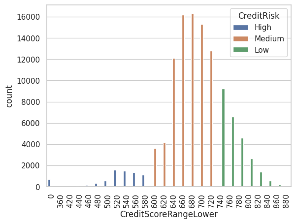

```python
# Checking CreditRisk values
sns.countplot(data=df_new,x='CreditScoreRangeLower',hue='CreditRisk')
plt.xticks(rotation=90);
```

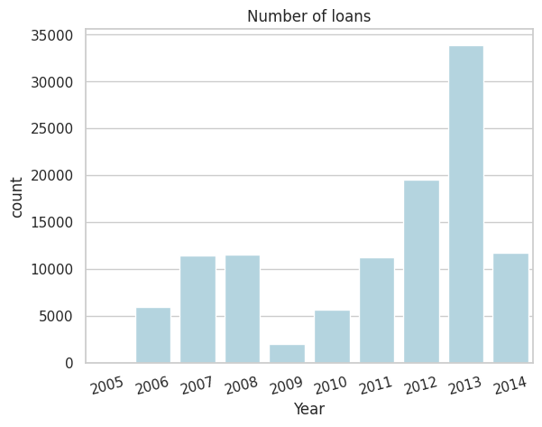

```python
# Loan disbursements over the period
sns.countplot(data=df_new,x='Year',color='lightblue')
plt.xticks(rotation=15)
plt.title('Number of loans');
```

```python
# saving cleaned subset
df_new.to_csv('cleaned_prosper.csv',index=False)
```

### Of the features you investigated, were there any unusual distributions? Did you perform any operations on the data to tidy, adjust, or change the form of the data? If so, why did you do this?

> - Reduced the number of income ranges by one by merging USD 0 with Not Employed into the same category.
> - Two listings with closed date before loan origination date has been removed

## Bivariate Exploration

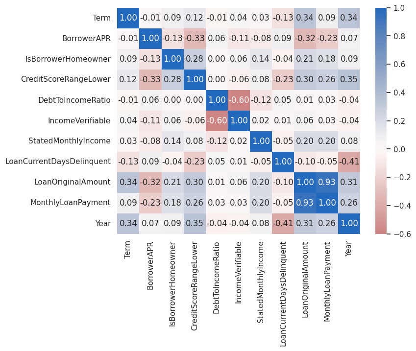

```python
# Correlation matrix
plt.figure(figsize=(8,6))
sns.heatmap(df_new[['Term','BorrowerAPR','IsBorrowerHomeowner','CreditScoreRangeLower',
                    'DebtToIncomeRatio','IncomeVerifiable', 'StatedMonthlyIncome',
                    'LoanCurrentDaysDelinquent', 'LoanOriginalAmount','MonthlyLoanPayment',
                    'Year']].corr(),cmap='vlag_r',annot=True,fmt='.2f',center=0)
plt.show();
```

- Interest rate and creditscore range has negative correlation.
- Debt to income ratio increases with decrease in income verifiable.
- Loan original amount has positive correlation with Monthly loan payment,Term and credit score range

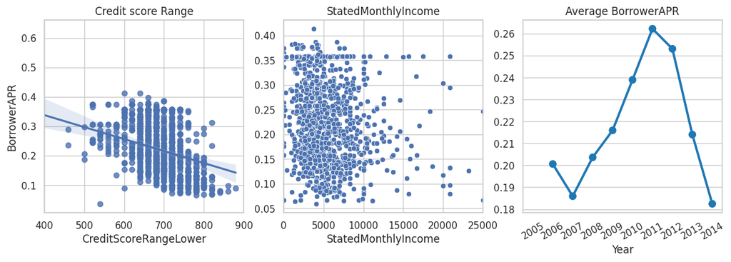

```python
# Borrower APR compared with other variables
# Credit score range Vs Borrower APR, to have clear view have taken 1000 samples
plt.figure(figsize=(14,4))
plt.subplot(1,3,1)
sns.regplot(data=df_new.sample(1000),x='CreditScoreRangeLower',y='BorrowerAPR')
plt.xlim(400,900)
plt.title('Credit score Range');
plt.subplot(1,3,2)
sns.scatterplot(data=df_new.sample(1000),x='StatedMonthlyIncome',y='BorrowerAPR')
plt.title('StatedMonthlyIncome')
plt.ylabel('')
plt.xlim(0,25000);
plt.subplot(1,3,3)
sns.pointplot(data=df_new,x='Year',y='BorrowerAPR', color='tab:blue',ci=None)
plt.ylabel('')
plt.xticks(rotation=30)
plt.title('Average BorrowerAPR');
```

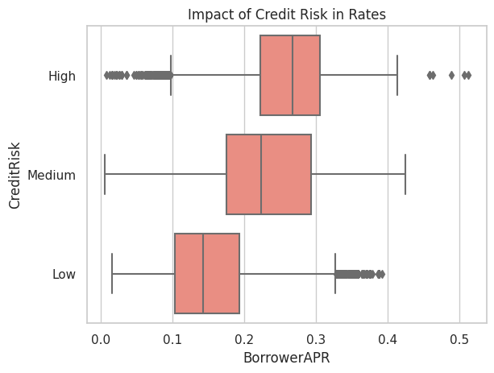

```python
#Impact of Credit Risk in interest rates
sns.boxplot(data=df_new,x='BorrowerAPR',y='CreditRisk', color='salmon')
plt.title('Impact of Credit Risk in Rates');
```

- Credit risk clearly separates interest rate of borrower. Higher the risk, higher the interest rate and vice versa

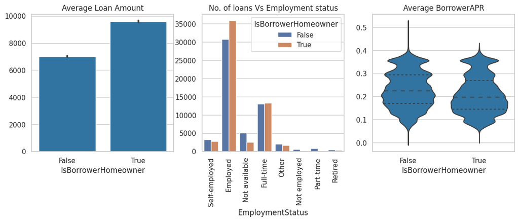

```python
# Comparing home ownership with other variables
plt.figure(figsize=(14,4))
plt.subplot(1,3,1)
sns.set_theme(style="whitegrid")
sns.barplot(data=df_new,x='IsBorrowerHomeowner',y='LoanOriginalAmount',color='tab:blue')
plt.title('Average Loan Amount')
plt.ylabel('')
plt.xticks(rotation=0);
plt.subplot(1,3,2)
sns.countplot(data=df_new,x='EmploymentStatus',hue='IsBorrowerHomeowner')
plt.title('No. of loans Vs Employment status')
plt.ylabel('')
plt.xticks(rotation=90);
plt.subplot(1,3,3)
sns.violinplot(data=df_new,x='IsBorrowerHomeowner',y='BorrowerAPR',color='tab:blue',inner='quartile')
plt.title('Average BorrowerAPR')
plt.ylabel('')
plt.xticks(rotation=0);
```

- Loan amount given to homeowners are higher than non-homeowners, due to reduced risk
- Most of the borrowers are employed
- Home owners gets loan at lower interest rate.

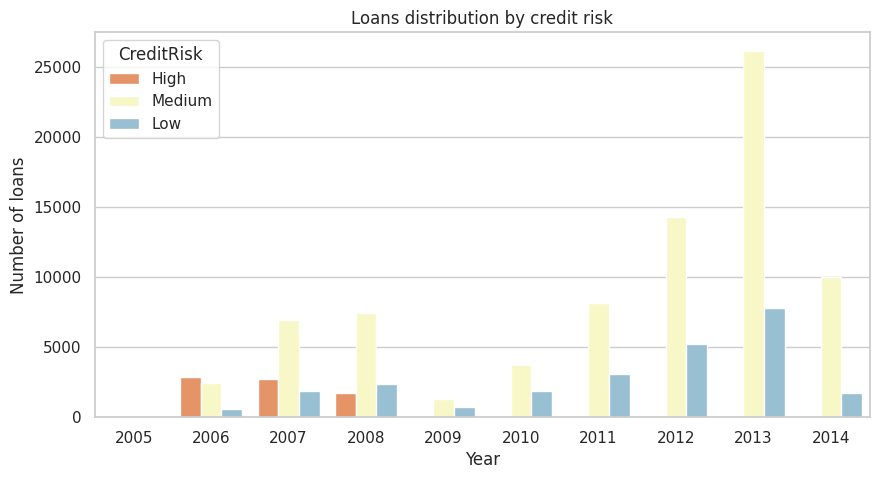

```python
#Loans distribution by credit risk
plt.figure(figsize = (10,5))
#plt.style.use('fivethirtyeight');
sns.countplot(data = df_new, x = 'Year', hue = 'CreditRisk', palette = 'RdYlBu')
plt.xlabel('Year')
plt.ylabel('Number of loans')
plt.title('Loans distribution by credit risk')
plt.legend(loc='upper left',title='CreditRisk');
```

- Number of loan disbursement is very high in the year 2013, High credit risk people didn't get loan from 2009 onwards

```python
# Making sample dataset
df_new.reset_index(inplace=True)
np.random.seed(42)
sample = np.random.choice(df_new.shape[0],900, replace = False)
df_subset = df_new.loc[sample]
```

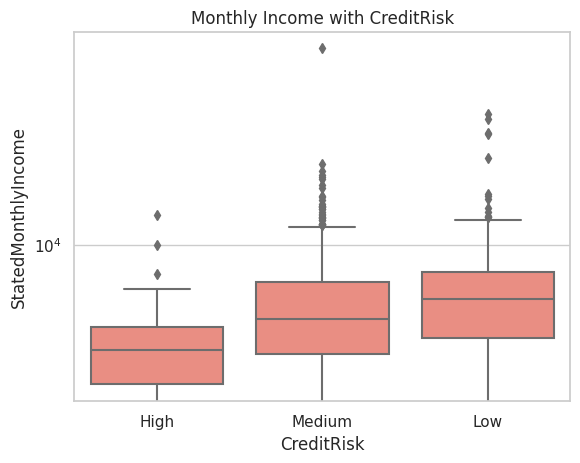

```python
# Checking Monthly Income with CreditRisk
sns.boxplot(data=df_subset,y='StatedMonthlyIncome',x='CreditRisk', color='salmon')
plt.title('Monthly Income with CreditRisk')
plt.yscale('log');
```

- Higher the monthly income lower the credit risk

### Talk about some of the relationships you observed in this part of the investigation. How did the feature(s) of interest vary with other features in the dataset?

- Borrower Interest rate negatively correlated with credit score range, loan original amount and monthly income.
- Credit risk clearly separates interest rate of borrower. Higher the risk, higher the interest rate and vice versa which is primary model of most of the lending business. 2009 onwards loan was given to medium and low credit risk people.
- Loan amount given to homeowners are higher than non-homeowners, due to reduced risk. They get loan at lower rate.

### Did you observe any interesting relationships between the other features (not the main feature(s) of interest)?

- Most of the borrowers are employed
- Debt to income ratio increases with decrease in income verifiable.
- Average interest rate increased till 2011, then it declines steeply.
- Number of loan disbursement is very high in the year 2013, High credit risk people didn't get loan from 2009 onwards

## Multivariate Exploration

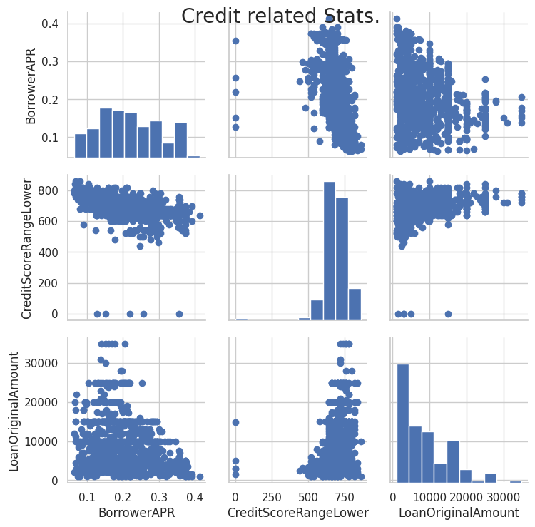

```python
#Pairplots - Credit related stats

variables = ['BorrowerAPR','CreditScoreRangeLower','LoanOriginalAmount']
g = sns.PairGrid(data=df_subset, vars=variables);
g.map_offdiag(plt.scatter);
g.map_diag(plt.hist);
plt.suptitle('Credit related Stats.',size=20);
```

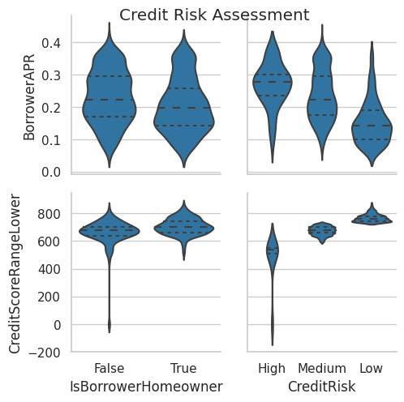

```python
""" Function for creating violinplots with seaborn's PairGrid. """
def plotvio(x, y, **kwargs):
    color = 'tab:blue'
    sns.violinplot(x, y, color = color,inner  ='quartile')

#plt.figure(figsize=(10,8));
x_vars = ['IsBorrowerHomeowner','CreditRisk']
y_vars = ['BorrowerAPR','CreditScoreRangeLower']
g = sns.PairGrid(data=df_subset, x_vars=x_vars, y_vars= y_vars);
g.map(plotvio);
plt.suptitle('Credit Risk Assessment');
```

- Owning home doesn't mean they have high credit score, but due to underlying security they do get loans at lower interest rate compare to non home owners

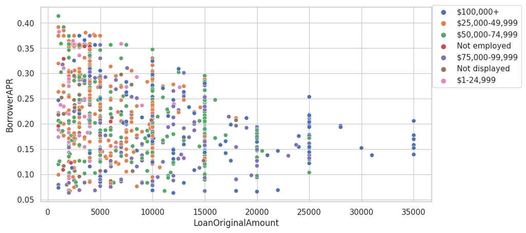

```python
# Does Income range affects Interest rate?
plt.figure(figsize=(10,5))
#sns.scatterplot(data=df_subset,x='LoanOriginalAmount',y='BorrowerAPR',hue='EmploymentStatus');
sns.scatterplot(data=df_subset,x='LoanOriginalAmount',y='BorrowerAPR',hue='IncomeRange')
plt.legend(loc='right',bbox_to_anchor=(1.24,0.8));
```

- Whoever falls in higher income range gets higher loan amount than their counterparts

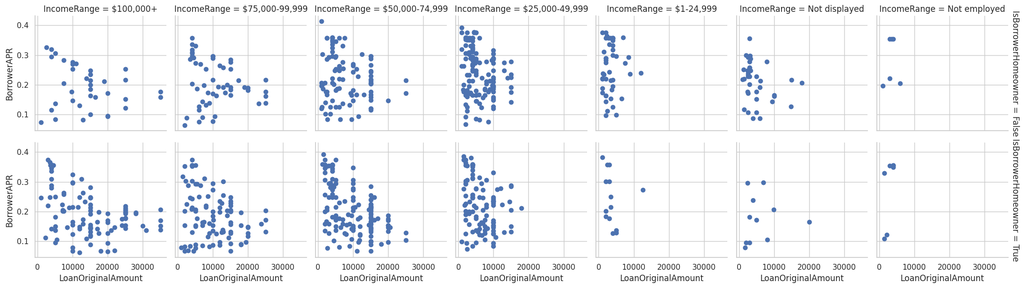

```python
# Checking income range subset by Faceting
order = ['$100,000+','$75,000-99,999','$50,000-74,999','$25,000-49,999','$1-24,999','Not displayed','Not employed']

g = sns.FacetGrid(data= df_subset, col='IncomeRange',col_order=order,row='IsBorrowerHomeowner',margin_titles=True)
g.map(plt.scatter, 'LoanOriginalAmount','BorrowerAPR');
```

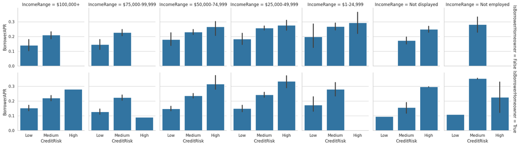

```python
# Faceting with credit risk
def bar_map(x,y,**kwargs):
    risk_order = ['Low','Medium','High']
    color='tab:blue'
    sns.barplot(x=x,y=y,order=risk_order,color=color)

order = ['$100,000+','$75,000-99,999','$50,000-74,999','$25,000-49,999','$1-24,999','Not displayed','Not employed']
g = sns.FacetGrid(data= df_subset, col='IncomeRange',col_order=order,row='IsBorrowerHomeowner',margin_titles=True)

g.map(bar_map,'CreditRisk','BorrowerAPR');
```

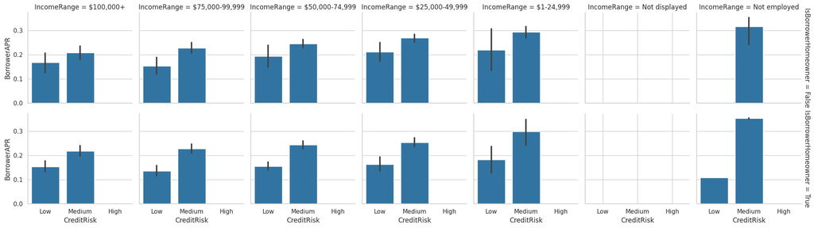

```python
# Making same plot with data after 2008
order = ['$100,000+','$75,000-99,999','$50,000-74,999','$25,000-49,999','$1-24,999','Not displayed','Not employed']
df_subset1 = df_subset[df_subset['Year']>2008]
g = sns.FacetGrid(data= df_subset1, col='IncomeRange',col_order=order,row='IsBorrowerHomeowner',margin_titles=True)
g.map(bar_map,'CreditRisk','BorrowerAPR');
```

- Facet plot helps to see people with lower income gets less loan amount with higher interest rate.
- Most of the borrowers falls in medium credit risk basket
- Having low credit risk doesn't mean they always get high loan amount
- There is no loan given to people whoever didn't disclose their income after 2008

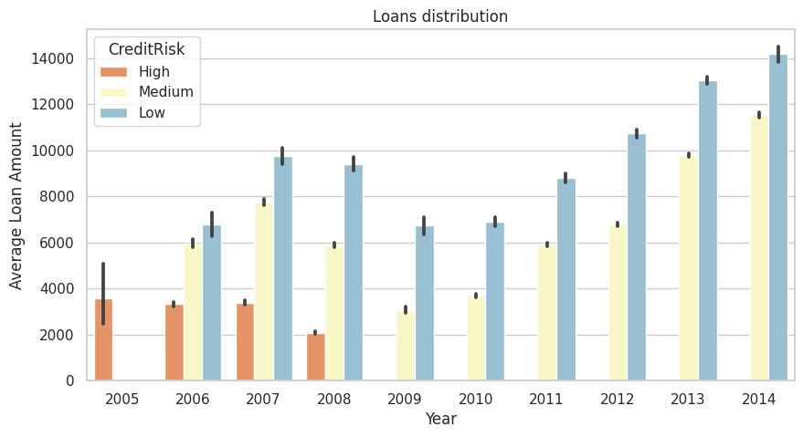

```python
# Loan distribution over the period
plt.figure(figsize = (10,5))
#plt.style.use('fivethirtyeight');
sns.barplot(data = df_new, x = 'Year',y='LoanOriginalAmount' ,hue = 'CreditRisk', palette = 'RdYlBu')
plt.ylabel('Average Loan Amount')
plt.title('Loans distribution')
plt.legend(loc='upper left',title='CreditRisk');
```

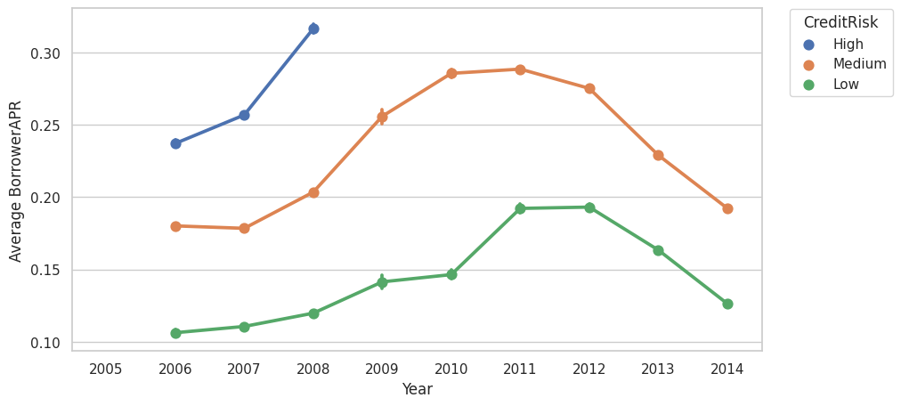

```python
# Change in interest rate over the period
plt.figure(figsize=(10,5))
sns.pointplot(data=df_new,x='Year',y='BorrowerAPR',hue='CreditRisk')
plt.ylabel('Average BorrowerAPR')
plt.legend(loc='right',title='CreditRisk',bbox_to_anchor=(1.2,0.87));
```

### Talk about some of the relationships you observed in this part of the investigation. Were there features that strengthened each other in terms of looking at your feature(s) of interest?

- Owning home doesn't mean they have high credit score, but due to underlying security they do get loans at lower interest rate compare to non home owners
- Whoever falls in higher income range gets higher loan amount than their counterparts
- Facet plot helps to see people with lower income gets less loan amount with higher interest rate.
- Most of the borrowers falls in medium credit risk basket

### Were there any interesting or surprising interactions between features?

- Having low credit risk doesn't mean they always get high loan amount
- Till 2011 Average loan amount was under USD 10000, 2013 onwards volume of loan increased thus the increase in average loan amount, Year 2009 onwards there is no disbursement of loan for high credit risk and undisclosed income borrower.

## Conclusions

Wherever risk is high returns also high, that echoes in lending business whenever they have high risk customer they will charge them more to balance the risk they take. Owning home doesn't mean they have high credit score, but due to underlying security they do get loans at lower interest rate than non home owners.

Income range does affect the loan amount they receive, low income people get less loan amount. Here in our dataset most of the borrowers are employed and have medium credit risk.Interest rate increased till 2011, then it declines. Due to decrease in interest rate, volume of loan disbursement increased in 2013.